# BIOS611_Proj1_Kitzmiller

Rebecca Kitzmiller

September 19, 2018

```
## # A tibble: 1 x 1
##   meanage
##     <dbl>
## 1    47.2
```

```
## # A tibble: 1 x 1
##   meantv
##    <dbl>
## 1   2.98
```

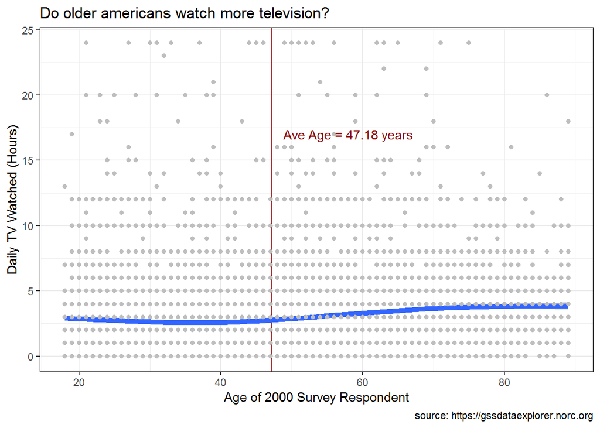

## The figure above was derived from the year 2000 General Social survey data. Conducted by the NORC, University of Chicago (https://gssdataexplorer.norc.org/) this annual survey is supported by National Science Foundation to provide data for a wide range of constituents including legislators, policymakers, researchers, etc. These data include the following categorical variables: survey year, participant demographics (age, race, marital status, income, political party affiliation, religion and religious denomination) and the number of hours spent watching TV each day.In 2000, n=21, 483 people responded to the survey. On average, respondents were 47 years old and reported watch television just less than 3 hours (2.98) each day. Although it does not appear to be a dramatic increase, time spent each day watching television increases as people age.

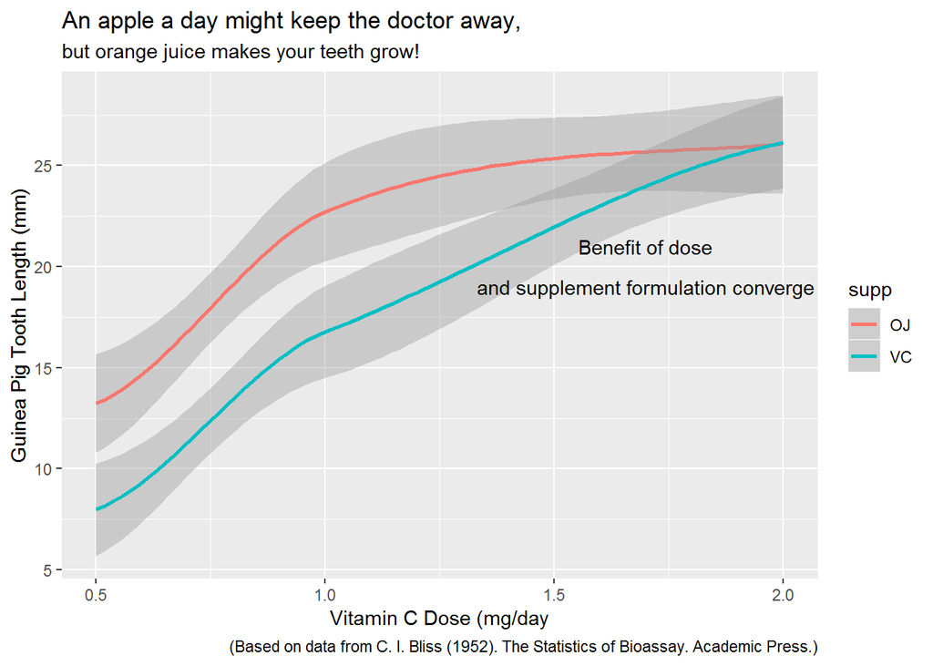

## Who knew that drinking orange juice daily might improve your teeth? Bliss (1952) evaluated the effect of two formulations of vitamin C (orange juice or ascorbic acid) in three daily dose amounts (0.5 mg, 1.0 mg, or 2.0 mg) on guinea pig tooth length (n=60 guinea pigs). He found that vitamin C in the orange juice formulation promoted more tooth growth then the ascorbic acid formulation. However, the effects of formulation appear to converge at the highest administered dose (2.0 mg/day). Unlike humans, guinea pigs’ teeth continue to grow throughout their lifetime. It is unclear if humans might also achieve tooth benefit from drinking orange juice since teeth form when babies are still in utero.

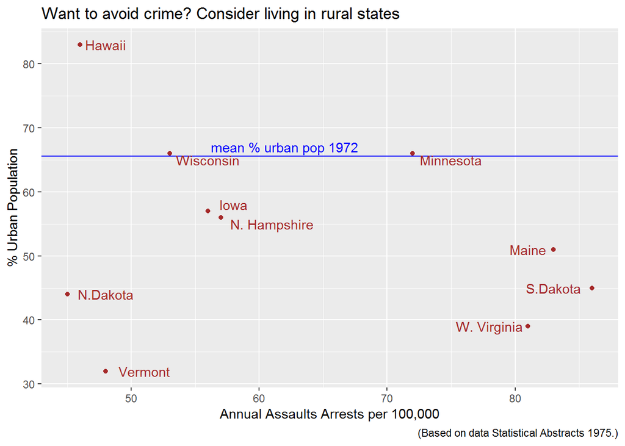

## The figure above represents 10 states in the US with the least number of Assault aressts in 1975. These data represent arrest data (murder, assault and rape) collect in 1975 (Statistical Abstracts 1975). Accept for Hawaii, where for than 80% of the population live in urban centers, the majority of th lowest crime states are rural.

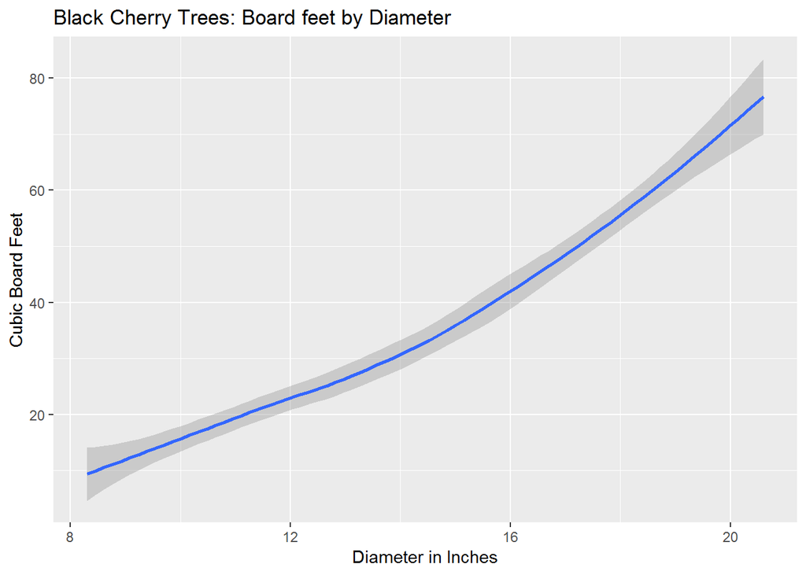

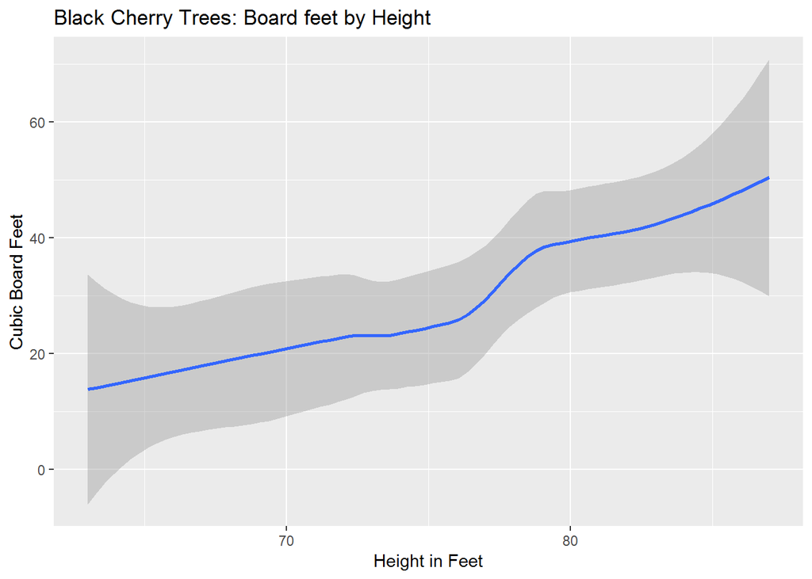